[figure not shown]

#### Modelos de Regressão para Dados de Contagem com o R

##### [`github.com/leg-ufpr/MRDCr`](https://github.com/leg-ufpr/MRDCr)

# Análise de Contagens com Modelo Gamma Gount

Walmes M. Zeviani, Eduardo E. Ribeiro Jr & Cesar A. Taconeli

## Função Densidade

Se uma variável aleatória $Y$ tem distribuição de probabilidades Gamma Count, então sua função de probabilidade é $p(y,\lambda,\alpha) = \left(\int_{0}^{1} \frac{(\alpha\lambda)^{y\alpha}}{\Gamma(y\alpha)}\, u^{y\alpha-1} \exp\{-\alpha\lambda u\}\, \textrm{d}u \right) - \left(\int_{0}^{1} \frac{(\alpha\lambda)^{y\alpha}}{\Gamma((y+1)\alpha)}\, u^{(y+1)\alpha-1} \exp\{-\alpha\lambda u\}\, \textrm{d}u \right),$ em que $\lambda$ é o parâmetro de locação e $\alpha$ o parâmetro de dispersão.

Essa função de probabilidade resulta da relação que existe entre intervalo de tempo entre eventos e do número de eventos dentro de um intervalo.

Considere que $\tau$ seja a variável aleatória tempo entre eventos que acontecem ao longo de um domínio com distribuição $\tau \sim \text{Gama}(\alpha, \beta)$. Sendo assim, a função desidade de $\tau$ é

$f(\tau, \alpha, \beta) = \frac{\beta^\alpha}{\Gamma(\alpha)} \cdot \tau^{\alpha-1}\cdot \exp\{-\beta\tau\},$ cuja média é $\text{E}(\tau) = \frac{\alpha}{\beta}$ e a variância é $\text{V}(\tau) = \frac{\alpha}{\beta^2}.$

Ainda, o tempo decorrido até a ocorrência o *n*-ésimo evento é portanto,

$\vartheta_n = \tau_1+\cdots+\tau_n ~ \sim \text{Gama}(n\alpha, \beta),$ pois a soma de variáveis aleatórias Gama tem distribuição Gama, cuja média é $\text{E}(\vartheta) = \frac{n\alpha}{\beta}$ e a variância é, $\text{V}(\vartheta) = \frac{n\alpha}{\beta^2}$. A função densidade de $\vartheta_n$ então é

$f_n(\vartheta, \alpha, \beta) = \frac{\beta^{n\alpha}}{\Gamma(n\alpha)}\cdot \vartheta^{n\alpha-1}\cdot \exp\{-\beta\vartheta\},$ e a função acumulada é

$F_n(T) = \Pr(\vartheta_n \leq T) = \int_{0}^{T} \frac{\beta^{n\alpha}}{\Gamma(n\alpha)}\cdot t^{n\alpha-1}\cdot \exp\{-\beta t\}\,\text{d}t.$

Decorre que, se $[0, T)$ é um intervalo e $N$ é o número de eventos ocorridos dentro desse intervalo, então $N < n$ se e somente se $\vartheta_n \geq T$, ou seja $\Pr(N < n) = \Pr(\vartheta_n \geq T) = 1-F_n(T).$

Como $F_n(T) = G(n\alpha, \beta T) = \frac{1}{\Gamma(n\alpha)} \int_{0}^{T} t^{n\alpha-1}\cdot\exp\{-\beta t\}\, \text{d}t,$ podemos escrever $\Pr(N = n)$ como sendo a diferença de acumuladas da Gama, $\Pr(N = n) = G(n\alpha, \beta T) - G((n+1)\alpha, \beta T).$

Em resumo, a distribuição para o número de eventos, quando se assume a distribuição do intervalo entre eventos é Gamma, é resultado da diferença de duas acumuladas da distribuição Gamma.

A média da variável de contagem é resultado de $\begin{align*} E(N) &= \sum_{i=0}^{\infty} i\cdot \Pr(i) \\ &= \sum_{i=1}^{\infty} i\cdot \Pr(i)\\ &= \sum_{i=1}^{\infty} G(i\alpha, \beta T).\\ \end{align*}$

Para um $T$ cada vez maior, tem-se que $N(T)\; \dot{\sim}\; \text{Normal}\left( \frac{\beta}{\alpha}, \frac{\beta}{\alpha^2}\right).$

Considere que $\frac{\beta}{\alpha} = \exp\{x^{\top}\theta\} \Rightarrow \beta = \alpha \exp\{x^{\top}\theta\}.$

Essa parametrização produz um modelo de regressão para a média do tempo entre eventos definida por $\text{E}(\tau|x) = \frac{\alpha}{\beta} = \exp\{-x^{\top}\theta\}.$

O modelo de regressão é para o tempo entre eventos ($\tau$) e não diretamente para contagem porque, a menos que $\alpha = 1$, não certo que $\text{E}(N_i|x_i) = [\text{E}(\tau_i|x_i)]^{-1}$. Dessa maneira, $-\theta$ mede a variação percentual do tempo médio entre eventos para uma unidade de $x$.

```r
# Definições da sessão.
library(lattice)
library(latticeExtra)
library(grid)
library(rpanel)
library(bbmle)
library(corrplot)
library(plyr)
library(car)
library(doBy)
library(multcomp)
library(MRDCr)
```

```r
# Função densidade na parametrização original.
dgcnt
```

```
## function(y, lambda, alpha) {
##     p <- pgamma(q = 1,
##                 shape = y * alpha,
##                 rate = alpha * lambda) -
##         pgamma(q = 1,
##                shape = (y + 1) * alpha,
##                rate = alpha * lambda)
##     return(p)
## }
## <environment: namespace:MRDCr>
```

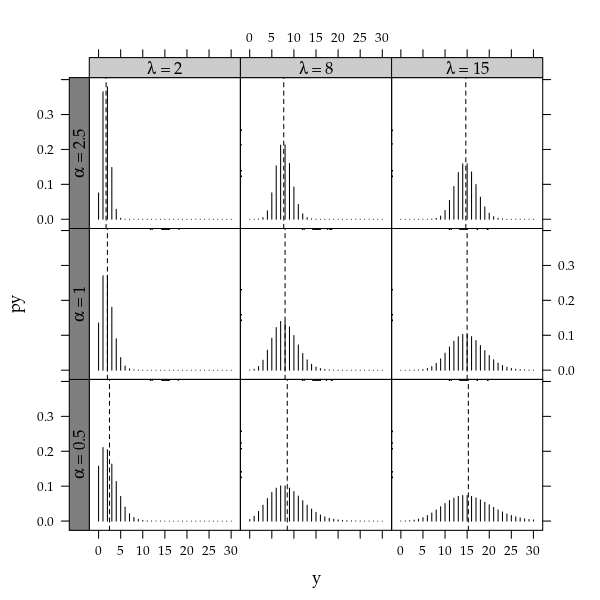

```r
# Caso Poisson (gamma == 0).
grid <- expand.grid(lambda = c(2, 8, 15),
                    alpha = c(0.5, 1, 2.5))
y <- 0:30
py <- mapply(FUN = dgcnt,
             lambda = grid$lambda,
             alpha = grid$alpha,
             MoreArgs = list(y = y), SIMPLIFY = FALSE)
grid <- cbind(grid[rep(1:nrow(grid), each = length(y)), ],
              y = y,
              py = unlist(py))

useOuterStrips(xyplot(py ~ y | factor(lambda) + factor(alpha),
                      data = grid, type = "h",
                      panel = function(x, y, ...) {
                          m <- sum(x * y)
                          panel.xyplot(x, y, ...)
                          panel.abline(v = m, lty = 2)
                          # grid.text(label = sprintf("%0.1f", m),
                          #           x = unit(0.95, "npc"),
                          #           y = unit(0.9, "npc"),
                          #           hjust = 1)
                      }),
               strip = strip.custom(
                   strip.names = TRUE,
                   var.name = expression(lambda == ""),
                   sep = ""),
               strip.left = strip.custom(
                   strip.names = TRUE,
                   var.name = expression(alpha == ""),
                   sep = ""))
```

## Recursos interativos com o `rpanel`

```r
# Função densidade na parametrização de modelo de regressão.
MRDCr::dgcnt

react <- function(panel){
    with(panel,
    {
        m <- LAMBDA
        s <- sqrt(LAMBDA/exp(ALPHA))
        y <- 0:max(c(YMAX, ceiling(m + 5 * s)))
        py <- dgcnt(y = y, lambda = LAMBDA, alpha = exp(ALPHA))
        if (POIS) {
            pz <- dpois(y, lambda = m)
        } else {
            pz <- 0
        }
        py[!is.finite(py)] <- 0
        plot(py ~ y, type = "h",
             ylim = c(0, max(c(py, pz))),
                 xlab = expression(y),
             ylab = expression(f(y)))
        mtext(side = 3,
              text = substitute(sum(f(y)) == s,
                                list(s = round(sum(py), 5))))
        if (EX) {
            m <- sum(y * py)
            # v <- sum((y - m)^2 * py)
            legend("topright", bty = "n",
                   legend = substitute(E(Y) == mu,
                                       list(mu = m)))
            abline(v = m, col = 2)
        }
        if (POIS) {
            lines(y + 0.3, pz, type = "h", col = 3)
        }
    })
    panel
}

panel <- rp.control(title = "Gamma Count",
                    size = c(300, 100), YMAX = 50)
rp.slider(panel = panel, action = react,
          variable = LAMBDA, title = "lambda",
          from = 1, to = 0.75 * panel$YMAX,
          initval = 5, resolution = 0.1,
          showvalue = TRUE)
rp.slider(panel = panel, action = react,
          variable = ALPHA, title = "alpha",
          from = -5, to = 5,
          initval = 0, resolution = 0.02,
          showvalue = TRUE)
rp.checkbox(panel = panel,
            variable = EX, action = react, title = "E(Y)",
            labels = "Mostrar o valor esperado?")
rp.checkbox(panel = panel,
            variable = POIS, action = react, title = "Poisson",
            labels = "Adicionar a distribução Poisson?")
rp.do(panel = panel, action = react)
```

## Verossimilhança e Estimação

```r
#-----------------------------------------------------------------------
# Função de log-Verossimilhança da Poisson Generalizada na
# parametrização de modelo de regressão.

MRDCr::llgcnt
```

```
## function(params, y, X, offset = NULL) {
##     # params: vetor de parâmetros;
##     #   params[1]: parâmetro de dispersão (alpha);
##     #   params[-1]: parâmetro de locação (lambda);
##     # y: variável resposta (contagem);
##     # X: matriz do modelo linear;
##     # offset: tamanho do domínio onde y foi medido (exposição);
##     #----------------------------------------
##     if (is.null(offset)) {
##         offset <- 1L
##     }
##     alpha <- exp(params[1])
##     eXb <- exp(X %*% params[-1])
##     alpha.eXb <- alpha * eXb
##     alpha.y <- alpha * y
##     # returns the log-likelihood.
##     ll <- -sum(log(pgamma(offset,
##                           shape = alpha.y,
##                           rate = alpha.eXb) -
##                    pgamma(offset,
##                           shape = alpha.y + alpha,
##                           rate = alpha.eXb)))
##     # Negativo da log-likelihood.
##     return(ll)
## }
## <environment: namespace:MRDCr>
```

```r
#-----------------------------------------------------------------------
# Gerando uma amostra aleatória da Poisson, para teste.

# Offset = 2, lambda = 3.
y <- rpois(100, lambda = 2 * 3)

L <- list(y = y,
          offset = rep(2, length(y)),
          X = cbind(rep(1, length(y))))

start <- c(alpha = 0, lambda = 1)
parnames(llgcnt) <- names(start)

# Como \alpha foi fixado em 1, essa ll corresponde à Poisson.
n0 <- mle2(minuslogl = llgcnt,
           start = start, data = L,
           fixed = list(alpha = 0), vecpar = TRUE)

# Para conferir.
c(coef(n0)["lambda"],
  coef(glm(y ~ offset(log(L$offset)), family = poisson)))
```

```
##      lambda (Intercept)
##     1.05779     1.05779
```

```r
# Estimando o \alpha.
n1 <- mle2(llgcnt, start = start, data = L, vecpar = TRUE)
coef(n1)
```

```
##       alpha      lambda
## -0.07677751  1.05083459
```

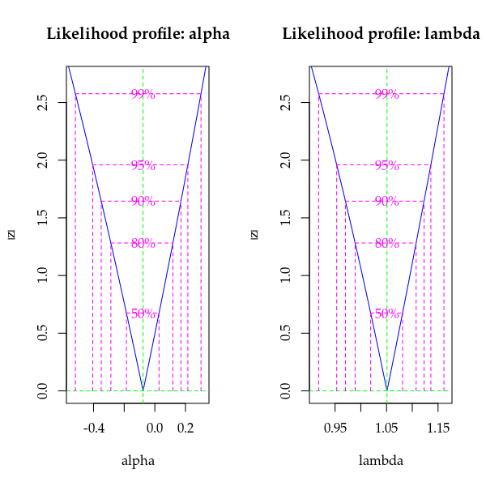

```r
# Perfil de verossimilhança dos parâmetros.
plot(profile(n1))
```

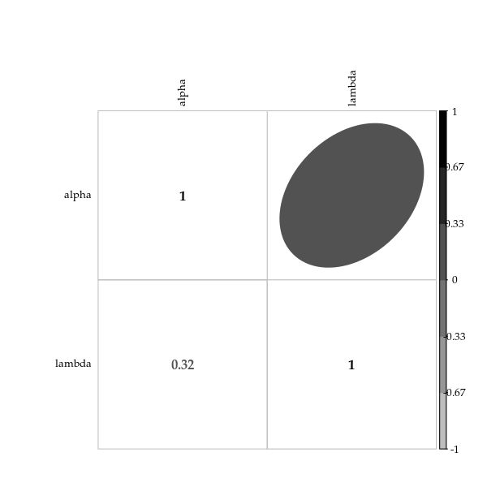

```r
# Covariância.
V <- cov2cor(vcov(n1))
corrplot.mixed(V, lower = "number", upper = "ellipse",
               diag = "l", tl.pos = "lt", tl.col = "black",
               tl.cex = 0.8, col = brewer.pal(9, "Greys")[-(1:3)])
```

```r
dev.off()
```

```r
# TODO documentar no pacote.
fitted.gcnt <- function(lambda, alpha, offset = NULL, ymax = 40) {
    if (is.null(offset)) {
        offset <- 1
    }
    pars <- cbind(lambda, alpha, offset)
    y <- 1:ymax
    py <- apply(pars, MARGIN = 1,
                FUN = function(p) {
                    sum(pgamma(p[3],
                               shape = p[2] * y,
                               rate = p[2] * p[1]))
                    # sum(y * dgcnt(y = y, lambda = p[1], alpha = p[2]))
                })
    names(py) <- NULL
    return(py)
}

mean(y)
```

```
## [1] 5.76
```

```r
fitted.gcnt(lambda = exp(coef(n1)[2]),
            alpha = exp(coef(n1)[1]),
            offset = 2)
```

```
## [1] 5.759969
```

```r
#-----------------------------------------------------------------------
# A média da Gamma-Count.

y <- rpois(100, lambda = 5)
L <- list(y = y, X = cbind(rep(1, length(y))))
start <- c(alpha = 0, lambda = 1)
parnames(llgcnt) <- names(start)
n1 <- mle2(llgcnt, start = start, data = L, vecpar = TRUE)

c(mean(y),
  exp(coef(n1)[2]),
  fitted.gcnt(lambda = exp(coef(n1)[2]), alpha = exp(coef(n1)[1])))
```

```
##            lambda
## 4.880000 4.940317 4.880021
```

```r
y <- rpois(500, lambda = 50)
L <- list(y = y, X = cbind(rep(1, length(y))))
start <- c(alpha = 0, lambda = 1)
parnames(llgcnt) <- names(start)
n1 <- mle2(llgcnt, start = start, data = L, vecpar = TRUE)

c(mean(y),
  exp(coef(n1)[2]),
  fitted.gcnt(lambda = exp(coef(n1)[2]),
              alpha = exp(coef(n1)[1]), ymax = 100))
```

```
##            lambda
## 49.98200 49.97672 49.98202
```

## Número de Vagens Produzidas em Soja

Resultados de um experimento fatorial (3 x 5), em delineamento de blocos casualizados, que estudou a influência de níveis de potássio na adubação de soja em combinação com irrigação em casa de vegetação. As variáveis de contagem registradas nesse experimento foram o número de vagens viáveis (e não viáveis) e o número total de sementes por parcela com duas plantas de soja.

```r
#-----------------------------------------------------------------------
# Carregando e explorando os dados.

data(soja, package = "MRDCr")
str(soja)
```

```
## 'data.frame':    75 obs. of  5 variables:
##  $ K   : int  0 30 60 120 180 0 30 60 120 180 ...
##  $ umid: Factor w/ 3 levels "37,5","50","62,5": 1 1 1 1 1 2 2 2 2 2 ...
##  $ bloc: Factor w/ 5 levels "I","II","III",..: 1 1 1 1 1 1 1 1 1 1 ...
##  $ ngra: int  136 159 156 171 190 140 193 200 208 237 ...
##  $ nvag: int  56 62 66 68 82 63 86 94 86 97 ...
```

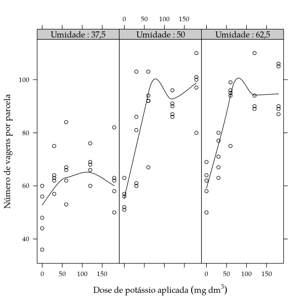

```r
# help(soja, package = "MRDCr", help_type = "html")

# A observação 74 é um outlier.
soja <- soja[-74, ]

xyplot(nvag ~ K | umid, data = soja, layout = c(NA, 1),
       type = c("p", "smooth"),
       ylab = "Número de vagens por parcela",
       xlab = expression("Dose de potássio aplicada"~(mg ~ dm^{3})),
       strip = strip.custom(strip.names = TRUE, var.name = "Umidade"))
```

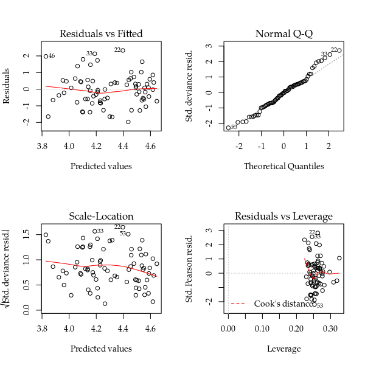

```r
soja <- transform(soja, K = factor(K))

#-----------------------------------------------------------------------
# Modelo Poisson.

m0 <- glm(nvag ~ bloc + umid * K, data = soja, family = poisson)
m1 <- update(m0, family = quasipoisson)

# Diagnóstico.
par(mfrow = c(2, 2))
plot(m0); layout(1)
```

```r
# Medidas de decisão.
# anova(m0, test = "Chisq")
anova(m1, test = "F")
```

```
## Analysis of Deviance Table
##
## Model: quasipoisson, link: log
##
## Response: nvag
##
## Terms added sequentially (first to last)
##
##
##        Df Deviance Resid. Df Resid. Dev       F    Pr(>F)
## NULL                      73     322.68
## bloc    4   14.284        69     308.40  2.9785   0.02684 *
## umid    2   92.911        67     215.49 38.7485 3.157e-11 ***
## K       4  136.060        63      79.43 28.3719 8.316e-13 ***
## umid:K  8   14.150        55      65.28  1.4754   0.18750
## ---
## Signif. codes:  0 '***' 0.001 '**' 0.01 '*' 0.05 '.' 0.1 ' ' 1
```

```r
summary(m1)
```

```
##
## Call:
## glm(formula = nvag ~ bloc + umid * K, family = quasipoisson,
##     data = soja)
##
## Deviance Residuals:
##     Min       1Q   Median       3Q      Max
## -1.9681  -0.6393  -0.0195   0.4854   2.3306
##
## Coefficients:
##               Estimate Std. Error t value Pr(>|t|)
## (Intercept)    3.95369    0.07547  52.389  < 2e-16 ***
## blocII        -0.02928    0.04479  -0.654 0.516036
## blocIII       -0.07265    0.04529  -1.604 0.114420
## blocIV        -0.12544    0.04592  -2.732 0.008457 **
## blocV         -0.10795    0.04705  -2.294 0.025606 *
## umid50         0.13404    0.09597   1.397 0.168117
## umid62,5       0.21656    0.09418   2.299 0.025303 *
## K30            0.27427    0.09300   2.949 0.004670 **
## K60            0.30797    0.09233   3.336 0.001530 **
## K120           0.32883    0.09192   3.577 0.000734 ***
## K180           0.25540    0.09338   2.735 0.008376 **
## umid50:K30     0.06322    0.12654   0.500 0.619324
## umid62,5:K30  -0.10747    0.12631  -0.851 0.398532
## umid50:K60     0.16561    0.12449   1.330 0.188897
## umid62,5:K60   0.10735    0.12286   0.874 0.386028
## umid50:K120    0.14920    0.12414   1.202 0.234563
## umid62,5:K120  0.11839    0.12487   0.948 0.347229
## umid50:K180    0.30370    0.12439   2.441 0.017873 *
## umid62,5:K180  0.19838    0.12325   1.610 0.113208
## ---
## Signif. codes:  0 '***' 0.001 '**' 0.01 '*' 0.05 '.' 0.1 ' ' 1
##
## (Dispersion parameter for quasipoisson family taken to be 1.198902)
##
##     Null deviance: 322.684  on 73  degrees of freedom
## Residual deviance:  65.278  on 55  degrees of freedom
## AIC: NA
##
## Number of Fisher Scoring iterations: 4
```

```r
#-----------------------------------------------------------------------
# Modelo Poisson Generalizado.

L <- with(soja,
          list(y = nvag, offset = 1, X = model.matrix(m0)))

# Usa as estimativas do Poisson como valores iniciais para a PGen.
start <- c(alpha = 0, coef(m0))
parnames(llgcnt) <- names(start)

# Com alpha fixo em 0 corresponde à Poisson.
m2 <- mle2(llgcnt, start = start, data = L,
           fixed = list(alpha = 0), vecpar = TRUE)

# Mesma medida de ajuste e estimativas.
c(logLik(m2), logLik(m0))
```

```
## [1] -259.6165 -259.6165
```

```r
cbind(coef(m2)[-1], coef(m0))
```

```
##                      [,1]        [,2]
## (Intercept)    3.95368723  3.95368724
## blocII        -0.02927855 -0.02927854
## blocIII       -0.07265048 -0.07265048
## blocIV        -0.12543798 -0.12543798
## blocV         -0.10794857 -0.10794857
## umid50         0.13404356  0.13404356
## umid62,5       0.21656458  0.21656458
## K30            0.27427290  0.27427290
## K60            0.30796674  0.30796674
## K120           0.32883188  0.32883188
## K180           0.25540441  0.25540441
## umid50:K30     0.06322288  0.06322288
## umid62,5:K30  -0.10747272 -0.10747272
## umid50:K60     0.16561471  0.16561471
## umid62,5:K60   0.10735066  0.10735066
## umid50:K120    0.14920392  0.14920392
## umid62,5:K120  0.11838578  0.11838578
## umid50:K180    0.30369921  0.30369921
## umid62,5:K180  0.19837927  0.19837927
```

```r
# Gamma-Count estimando o alpha.
m3 <- mle2(llgcnt, start = start, data = L, vecpar = TRUE)

# Teste para nulinidade do parâmetro de dispersão (H_0: alpha == 0).
anova(m3, m2)
```

```
## Likelihood Ratio Tests
## Model 1: m3, [llgcnt]: alpha+(Intercept)+blocII+blocIII+blocIV+
##           blocV+umid50+umid62,5+K30+K60+K120+K180+
##           umid50:K30+umid62,5:K30+umid50:K60+umid62,5:K60+
##           umid50:K120+umid62,5:K120+umid50:K180+umid62,5:K180
## Model 2: m2, [llgcnt]: (Intercept)+blocII+blocIII+blocIV+blocV+
##           umid50+umid62,5+K30+K60+K120+K180+umid50:K30+
##           umid62,5:K30+umid50:K60+umid62,5:K60+umid50:K120+
##           umid62,5:K120+umid50:K180+umid62,5:K180
##   Tot Df Deviance  Chisq Df Pr(>Chisq)
## 1     20   518.65
## 2     19   519.23 0.5802  1     0.4462
```

```r
# Estimaitvas dos parâmetros.
c0 <- cbind("PoissonGLM" = c(NA, coef(m0)),
            "PoissonML" = coef(m2),
            "GCount" = coef(m3))
c0
```

```
##                PoissonGLM   PoissonML      GCount
##                        NA  0.00000000  0.12875777
## (Intercept)    3.95368724  3.95368723  3.95487435
## blocII        -0.02927854 -0.02927855 -0.02925363
## blocIII       -0.07265048 -0.07265048 -0.07259276
## blocIV        -0.12543798 -0.12543798 -0.12534177
## blocV         -0.10794857 -0.10794857 -0.10785674
## umid50         0.13404356  0.13404356  0.13388357
## umid62,5       0.21656458  0.21656458  0.21632039
## K30            0.27427290  0.27427290  0.27397250
## K60            0.30796674  0.30796674  0.30763762
## K120           0.32883188  0.32883188  0.32848139
## K180           0.25540441  0.25540441  0.25512492
## umid50:K30     0.06322288  0.06322288  0.06321988
## umid62,5:K30  -0.10747272 -0.10747272 -0.10732539
## umid50:K60     0.16561471  0.16561471  0.16553912
## umid62,5:K60   0.10735066  0.10735066  0.10734196
## umid50:K120    0.14920392  0.14920392  0.14914452
## umid62,5:K120  0.11838578  0.11838578  0.11838048
## umid50:K180    0.30369921  0.30369921  0.30351780
## umid62,5:K180  0.19837927  0.19837927  0.19829595
```

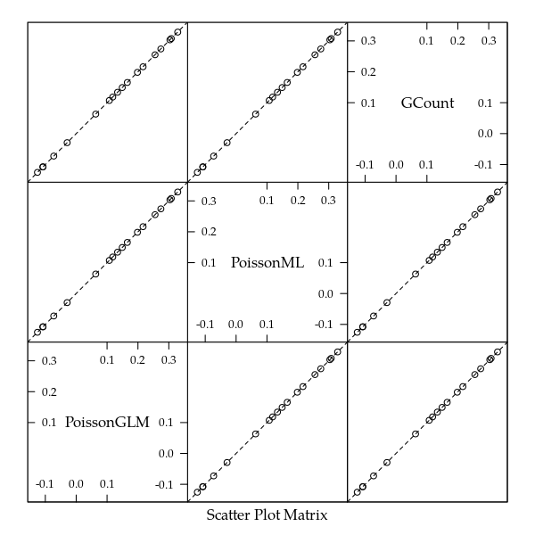

```r
splom(c0[-(1:2), ]) + layer(panel.abline(a = 0, b = 1, lty = 2))
```

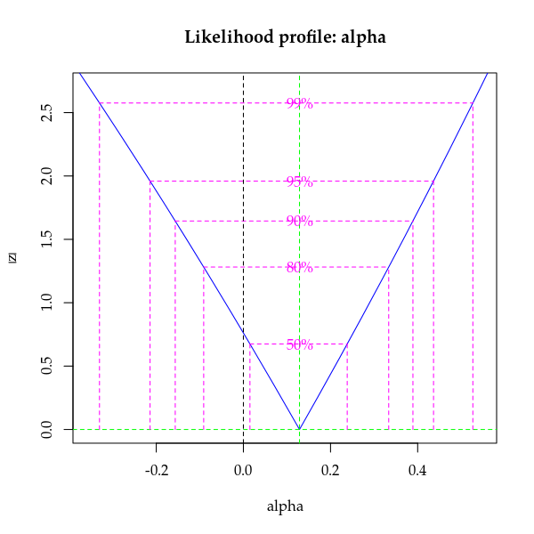

```r
# Perfil para o parâmetro de dispersão.
plot(profile(m3, which = "alpha"))
abline(v = 0, lty = 2)
```

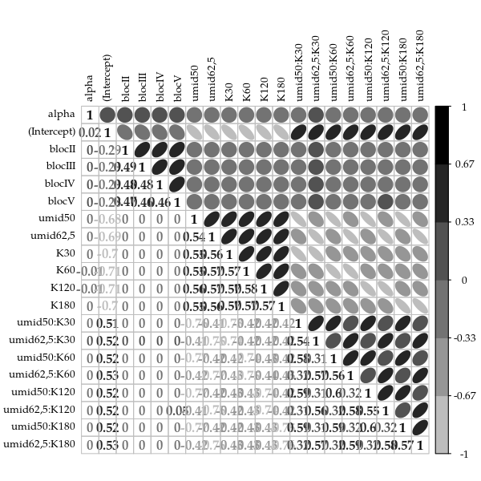

```r
V <- cov2cor(vcov(m3))
corrplot.mixed(V, lower = "number", upper = "ellipse",
               diag = "l", tl.pos = "lt", tl.col = "black",
               tl.cex = 0.8, col = brewer.pal(9, "Greys")[-(1:3)])
```

```r
dev.off()
```

```r
# Tamanho das covariâncias com \alpha.
each(sum, mean, max)(abs(V[1, -1]))
```

```
##         sum        mean         max
## 0.061875318 0.003256596 0.022121891
```

```r
#-----------------------------------------------------------------------
# Testes de hipótese.

# Teste de Wald para a interação.
a <- c(0, attr(model.matrix(m0), "assign"))
ai <- a == max(a)
L <- t(replicate(sum(ai), rbind(coef(m3) * 0), simplify = "matrix"))
L[, ai] <- diag(sum(ai))

# Cáclculo da estatística Chi-quadrado.
crossprod(L %*% coef(m3),
          solve(L %*% vcov(m3) %*% t(L),
                L %*% coef(m3)))
```

```
##          [,1]
## [1,] 15.96558
```

```r
# Teste de Wald para interação (poderia ser LRT, claro).
# É necessário passar um objeto glm mesmo fornecendo o restante a parte.
linearHypothesis(model = m0,
                 hypothesis.matrix = L,
                 vcov. = vcov(m3),
                 coef. = coef(m3))
```

```
## Linear hypothesis test
##
## Hypothesis:
## umid50:K30 = 0
## umid62,5:K30 = 0
## umid50:K60 = 0
## umid62,5:K60 = 0
## umid50:K120 = 0
## umid62,5:K120 = 0
## umid50:K180 = 0
## umid62,5:K180 = 0
##
## Model 1: restricted model
## Model 2: nvag ~ bloc + umid * K
##
## Note: Coefficient covariance matrix supplied.
##
##   Res.Df Df  Chisq Pr(>Chisq)
## 1     63
## 2     55  8 15.966    0.04288 *
## ---
## Signif. codes:  0 '***' 0.001 '**' 0.01 '*' 0.05 '.' 0.1 ' ' 1
```

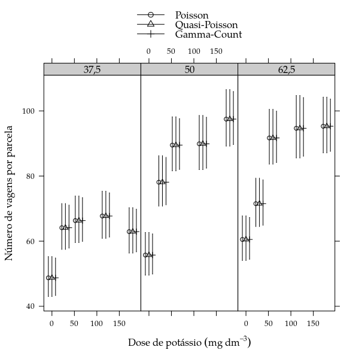

```r
#-----------------------------------------------------------------------
# Predição com bandas de confiança.

X <- LSmatrix(m0, effect = c("umid", "K"))
pred <- attr(X, "grid")
pred <- transform(pred,
                  K = as.integer(K),
                  umid = factor(umid))
pred <- list(pois = pred, quasi = pred, gcnt = pred)

# Quantil normal.
qn <- qnorm(0.975) * c(lwr = -1, fit = 0, upr = 1)

# Preditos pela Poisson.
aux <- confint(glht(m0, linfct = X),
               calpha = univariate_calpha())$confint
colnames(aux)[1] <- "fit"
pred$pois <- cbind(pred$pois, exp(aux))

# Preditos pela Quasi-Poisson.
aux <- confint(glht(m0, linfct = X),
               calpha = univariate_calpha())$confint
colnames(aux)[1] <- "fit"
pred$quasi <- cbind(pred$quasi, exp(aux))

# Matrix de covariância completa e sem o alpha (marginal).
V <- vcov(m3)
V <- V[-1, -1]
U <- chol(V)
aux <- sqrt(apply(X %*% t(U), MARGIN = 1,
                  FUN = function(x) { sum(x^2) }))
pred$gcnt$eta <- c(X %*% coef(m3)[-1])
pred$gcnt <- cbind(pred$gcnt,
                   apply(outer(aux, qn, FUN = "*"), MARGIN = 2,
                         FUN = function(x) {
                             # exp(pred$gcnt$eta + x)
                             fitted.gcnt(
                                 lambda = exp(pred$gcnt$eta + x),
                                 alpha = exp(coef(m3)["alpha"]),
                                 ymax = 300)
                         }))
pred$gcnt$eta <- NULL

pred <- ldply(pred, .id = "modelo")
pred <- arrange(pred, umid, K, modelo)

key <- list(type = "o", divide = 1,
            lines = list(pch = 1:nlevels(pred$modelo),
                         lty = 1, col = 1),
            text = list(c("Poisson", "Quasi-Poisson",
                          "Gamma-Count")))

xyplot(fit ~ K | umid, data = pred,
       layout = c(NA, 1), as.table = TRUE,
       xlim = extendrange(range(pred$K), f = 0.1),
       key = key, pch = pred$modelo,
       xlab = expression("Dose de potássio"~(mg~dm^{-3})),
       ylab = "Número de vagens por parcela",
       ly = pred$lwr, uy = pred$upr, cty = "bars", length = 0,
       prepanel = prepanel.cbH,
       desloc = 8 * scale(as.integer(pred$modelo), scale = FALSE),
       panel = panel.cbH)
```

## Número de Grãos Produzidas em Soja

Análise do número de grãos por pacela do experimento com soja.

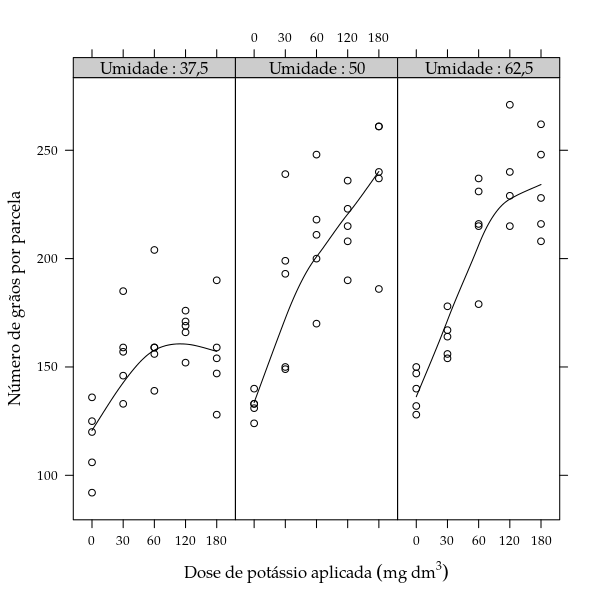

```r
#-----------------------------------------------------------------------

xyplot(ngra ~ K | umid, data = soja, layout = c(NA, 1),
       type = c("p", "smooth"),
       ylab = "Número de grãos por parcela",
       xlab = expression("Dose de potássio aplicada"~(mg ~ dm^{3})),
       strip = strip.custom(strip.names = TRUE, var.name = "Umidade"))
```

```r
# NOTE: Essa contagem é alta e uma análise preliminar não retornou
# Hessiana para o modelo Gamma-Count ajustado com a mle2. A suspeita que
# é seja pela ordem de magnitude dos dados. Sendo assim, vamos
# considerar um offset artifical de 10 apenas para correr as análises.
#
# Warning message:
# In mle2(llgcnt, start = start, data = L, fixed = list(alpha = 0),  :
#   couldn't invert Hessian
#
# Warning message:
# In mle2(llgcnt, start = start, data = L, vecpar = TRUE) :
#   couldn't invert Hessian

soja$off <- 10
fivenum(with(soja, ngra/off))
```

```
## [1]  9.20 14.70 17.05 21.60 27.10
```

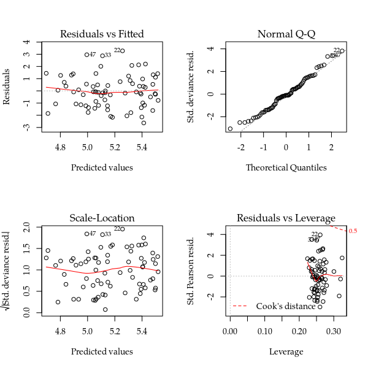

```r
#-----------------------------------------------------------------------
# Modelo Poisson.

m0 <- glm(ngra ~ offset(log(off)) + bloc + umid * K,
          data = soja, family = poisson)
m1 <- update(m0, family = quasipoisson)

# Diagnóstico.
par(mfrow = c(2, 2))
plot(m0); layout(1)
```

```r
# Medidas de decisão.
# anova(m0, test = "Chisq")
anova(m1, test = "F")
```

```
## Analysis of Deviance Table
##
## Model: quasipoisson, link: log
##
## Response: ngra
##
## Terms added sequentially (first to last)
##
##
##        Df Deviance Resid. Df Resid. Dev       F    Pr(>F)
## NULL                      73     761.43
## bloc    4    28.34        69     733.09  3.0962   0.02273 *
## umid    2   185.06        67     548.03 40.4318 1.584e-11 ***
## K       4   380.32        63     167.71 41.5466 5.186e-16 ***
## umid:K  8    42.99        55     124.72  2.3480   0.03004 *
## ---
## Signif. codes:  0 '***' 0.001 '**' 0.01 '*' 0.05 '.' 0.1 ' ' 1
```

```r
summary(m1)
```

```
##
## Call:
## glm(formula = ngra ~ offset(log(off)) + bloc + umid * K, family = quasipoisson,
##     data = soja)
##
## Deviance Residuals:
##     Min       1Q   Median       3Q      Max
## -2.6297  -1.0707  -0.0873   0.7428   3.2810
##
## Coefficients:
##               Estimate Std. Error t value Pr(>|t|)
## (Intercept)    2.49937    0.06773  36.902  < 2e-16 ***
## blocII        -0.01939    0.04017  -0.483 0.631230
## blocIII       -0.03663    0.04035  -0.908 0.367964
## blocIV        -0.10559    0.04107  -2.571 0.012884 *
## blocV         -0.09313    0.04218  -2.208 0.031433 *
## umid50         0.13245    0.08611   1.538 0.129739
## umid62,5       0.18548    0.08506   2.180 0.033517 *
## K30            0.29799    0.08299   3.591 0.000703 ***
## K60            0.34434    0.08218   4.190 0.000102 ***
## K120           0.36493    0.08183   4.459  4.1e-05 ***
## K180           0.29542    0.08303   3.558 0.000778 ***
## umid50:K30     0.04344    0.11318   0.384 0.702600
## umid62,5:K30  -0.13669    0.11386  -1.201 0.235081
## umid50:K60     0.11559    0.11136   1.038 0.303817
## umid62,5:K60   0.09174    0.11027   0.832 0.409039
## umid50:K120    0.11860    0.11088   1.070 0.289461
## umid62,5:K120  0.16266    0.11145   1.460 0.150096
## umid50:K180    0.28832    0.11085   2.601 0.011917 *
## umid62,5:K180  0.21569    0.11021   1.957 0.055430 .
## ---
## Signif. codes:  0 '***' 0.001 '**' 0.01 '*' 0.05 '.' 0.1 ' ' 1
##
## (Dispersion parameter for quasipoisson family taken to be 2.28854)
##
##     Null deviance: 761.43  on 73  degrees of freedom
## Residual deviance: 124.72  on 55  degrees of freedom
## AIC: NA
##
## Number of Fisher Scoring iterations: 4
```

```r
#-----------------------------------------------------------------------
# Modelo Poisson Generalizado.

L <- with(soja,
          list(y = ngra, offset = off, X = model.matrix(m0)))

# Usa as estimativas do Poisson como valores iniciais.
start <- c(alpha = 0, coef(m0))
parnames(llgcnt) <- names(start)

# Com alpha fixo em 0 corresponde à Poisson.
m2 <- mle2(llgcnt, start = start, data = L,
           fixed = list(alpha = 0), vecpar = TRUE)

# Mesma medida de ajuste e estimativas.
c(logLik(m2), logLik(m0))
```

```
## [1] -321.6692 -321.6692
```

```r
# Poisson Generalizada.
m3 <- mle2(llgcnt, start = start, data = L, vecpar = TRUE)

# Teste para nulinidade do parâmetro de dispersão (H_0: alpha == 0).
anova(m3, m2)
```

```
## Likelihood Ratio Tests
## Model 1: m3, [llgcnt]: alpha+(Intercept)+blocII+blocIII+blocIV+
##           blocV+umid50+umid62,5+K30+K60+K120+K180+
##           umid50:K30+umid62,5:K30+umid50:K60+umid62,5:K60+
##           umid50:K120+umid62,5:K120+umid50:K180+umid62,5:K180
## Model 2: m2, [llgcnt]: (Intercept)+blocII+blocIII+blocIV+blocV+
##           umid50+umid62,5+K30+K60+K120+K180+umid50:K30+
##           umid62,5:K30+umid50:K60+umid62,5:K60+umid50:K120+
##           umid62,5:K120+umid50:K180+umid62,5:K180
##   Tot Df Deviance  Chisq Df Pr(>Chisq)
## 1     20   631.29
## 2     19   643.34 12.051  1  0.0005176 ***
## ---
## Signif. codes:  0 '***' 0.001 '**' 0.01 '*' 0.05 '.' 0.1 ' ' 1
```

```r
# Estimaitvas dos parâmetros.
c0 <- cbind("PoissonGLM" = c(NA, coef(m0)),
            "PoissonML" = coef(m2),
            "GCount" = coef(m3))
c0
```

```
##                PoissonGLM   PoissonML      GCount
##                        NA  0.00000000 -0.52305059
## (Intercept)    2.49937463  2.49937463  2.49649191
## blocII        -0.01939070 -0.01939070 -0.01943043
## blocIII       -0.03662632 -0.03662632 -0.03669577
## blocIV        -0.10559332 -0.10559332 -0.10578690
## blocV         -0.09313375 -0.09313375 -0.09331619
## umid50         0.13245136  0.13245136  0.13282522
## umid62,5       0.18548293  0.18548293  0.18598885
## K30            0.29799144  0.29799144  0.29876306
## K60            0.34433662  0.34433662  0.34520871
## K120           0.36493092  0.36493092  0.36585027
## K180           0.29542405  0.29542405  0.29619069
## umid50:K30     0.04343930  0.04343930  0.04341282
## umid62,5:K30  -0.13669277 -0.13669277 -0.13709575
## umid50:K60     0.11559375  0.11559375  0.11568092
## umid62,5:K60   0.09174072  0.09174072  0.09174645
## umid50:K120    0.11859658  0.11859658  0.11867938
## umid62,5:K120  0.16266223  0.16266223  0.16275434
## umid50:K180    0.28832017  0.28832017  0.28870557
## umid62,5:K180  0.21568848  0.21568848  0.21591249
```

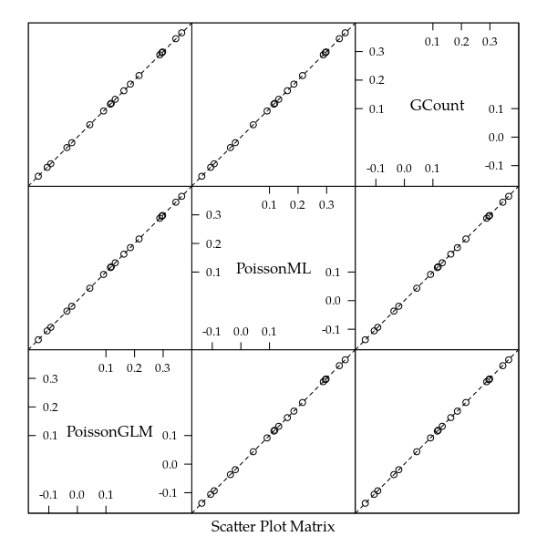

```r
splom(c0[-(1:2), ]) + layer(panel.abline(a = 0, b = 1, lty = 2))
```

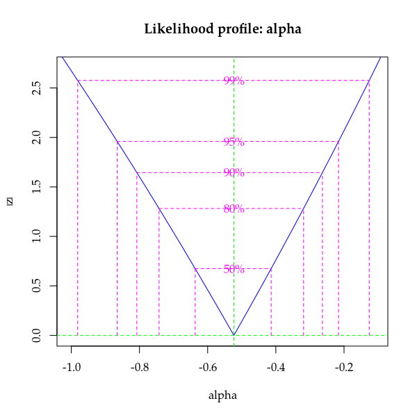

```r
# Perfil para o parâmetro de dispersão.
plot(profile(m3, which = "alpha"))
abline(v = 0, lty = 2)
```

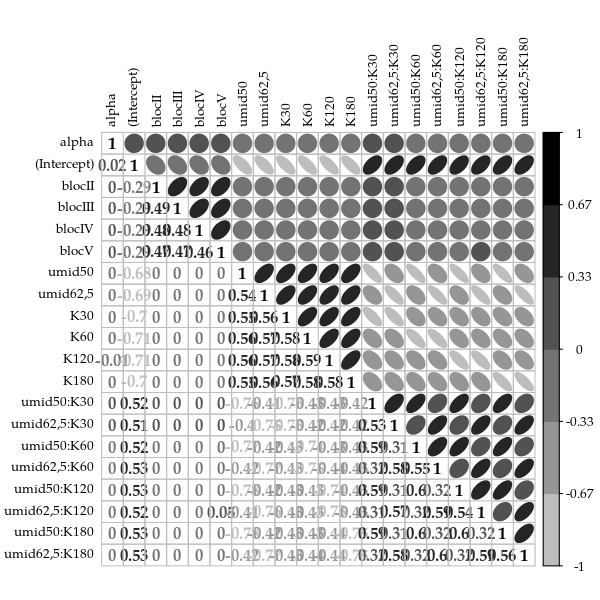

```r
V <- cov2cor(vcov(m3))
corrplot.mixed(V, lower = "number", upper = "ellipse",
               diag = "l", tl.pos = "lt", tl.col = "black",
               tl.cex = 0.8, col = brewer.pal(9, "Greys")[-(1:3)])
```

```r
dev.off()
```

```r
# Tamanho das covariâncias com \alpha.
each(sum, mean, max)(abs(V[1, -1]))
```

```
##         sum        mean         max
## 0.054983277 0.002893857 0.020065055
```

```r
# Teste de Wald para a interação.
a <- c(0, attr(model.matrix(m0), "assign"))
ai <- a == max(a)
L <- t(replicate(sum(ai), rbind(coef(m3) * 0), simplify = "matrix"))
L[, ai] <- diag(sum(ai))

# Cáclculo da estatística Chi-quadrado.
crossprod(L %*% coef(m3),
          solve(L %*% vcov(m3) %*% t(L),
                L %*% coef(m3)))
```

```
##          [,1]
## [1,] 25.28744
```

```r
linearHypothesis(model = m0,
                 hypothesis.matrix = L,
                 vcov. = vcov(m3),
                 coef. = coef(m3))
```

```
## Linear hypothesis test
##
## Hypothesis:
## umid50:K30 = 0
## umid62,5:K30 = 0
## umid50:K60 = 0
## umid62,5:K60 = 0
## umid50:K120 = 0
## umid62,5:K120 = 0
## umid50:K180 = 0
## umid62,5:K180 = 0
##
## Model 1: restricted model
## Model 2: ngra ~ offset(log(off)) + bloc + umid * K
##
## Note: Coefficient covariance matrix supplied.
##
##   Res.Df Df  Chisq Pr(>Chisq)
## 1     63
## 2     55  8 25.287   0.001389 **
## ---
## Signif. codes:  0 '***' 0.001 '**' 0.01 '*' 0.05 '.' 0.1 ' ' 1
```

```r
#-----------------------------------------------------------------------
# Predição com bandas de confiança.

# Por causa do offset, não tem como usar a LSmatrix.
pred <- unique(subset(soja, select = c("umid", "K")))
X <- model.matrix(formula(m0)[-2],
                  data = cbind(off = 1, bloc = soja$bloc[1], pred))
i <- grep(x = colnames(X), pattern = "^bloc")
X[, i] <- X[, i] * 0 + 1/(length(i) + 1)

pred <- transform(pred,
                  K = as.numeric(as.character(K)),
                  umid = factor(umid))
pred <- list(pois = pred, quasi = pred, gcnt = pred)

# Quantil normal.
qn <- qnorm(0.975) * c(lwr = -1, fit = 0, upr = 1)

# Preditos pela Poisson.
aux <- confint(glht(m0, linfct = X),
               calpha = univariate_calpha())$confint
colnames(aux)[1] <- "fit"
pred$pois <- cbind(pred$pois, exp(aux))

# Preditos pela Quasi-Poisson.
aux <- confint(glht(m1, linfct = X),
               calpha = univariate_calpha())$confint
colnames(aux)[1] <- "fit"
pred$quasi <- cbind(pred$quasi, exp(aux))

# Matrix de covariância completa e sem o alpha (marginal).
V <- vcov(m3)
V <- V[-1, -1]
U <- chol(V)
aux <- sqrt(apply(X %*% t(U), MARGIN = 1,
                  FUN = function(x) { sum(x^2) }))
pred$gcnt$eta <- c(X %*% coef(m3)[-1])
pred$gcnt <- cbind(pred$gcnt,
                   apply(outer(aux, qn, FUN = "*"), MARGIN = 2,
                         FUN = function(x) {
                             exp(pred$gcnt$eta + x)
                             # fitted.gcnt(
                             #     lambda = exp(pred$gcnt$eta + x),
                             #     alpha = exp(coef(m3)["alpha"]),
                             #     ymax = 100)
                         }))
pred$gcnt$eta <- NULL

# Junta o resultado dos 3 modelos.
pred <- ldply(pred, .id = "modelo")
pred <- arrange(pred, umid, K, modelo)
str(pred)
```

```
## 'data.frame':    45 obs. of  6 variables:
##  $ modelo: Factor w/ 3 levels "pois","quasi",..: 1 2 3 1 2 3 1 2 3 1 ...
##  $ umid  : Factor w/ 3 levels "37,5","50","62,5": 1 1 1 1 1 1 1 1 1 1 ...
##  $ K     : num  0 0 0 30 30 30 60 60 60 120 ...
##  $ fit   : num  11.6 11.6 11.5 15.6 15.6 ...
##  $ lwr   : num  10.7 10.2 10.4 14.5 14 ...
##  $ upr   : num  12.6 13.1 12.8 16.7 17.3 ...
```

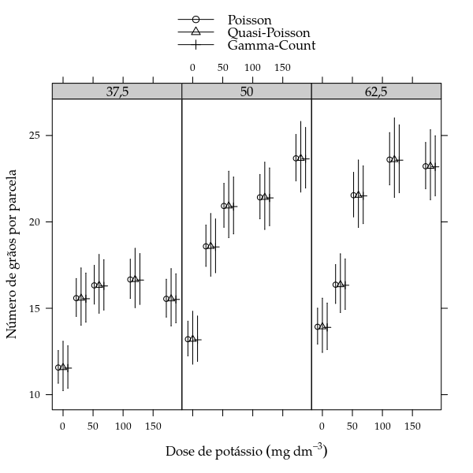

```r
key <- list(type = "o", divide = 1,
            lines = list(pch = 1:nlevels(pred$modelo),
                         lty = 1, col = 1),
            text = list(c("Poisson", "Quasi-Poisson",
                          "Gamma-Count")))

xyplot(fit ~ K | umid, data = pred,
       layout = c(NA, 1), as.table = TRUE,
       xlim = extendrange(range(pred$K), f = 0.1),
       key = key, pch = pred$modelo,
       xlab = expression("Dose de potássio"~(mg~dm^{-3})),
       ylab = "Número de grãos por parcela",
       ly = pred$lwr, uy = pred$upr, cty = "bars", length = 0,
       prepanel = prepanel.cbH,
       desloc = 8 * scale(as.integer(pred$modelo), scale = FALSE),
       panel = panel.cbH)
```

## Número de Grãos por Vagem

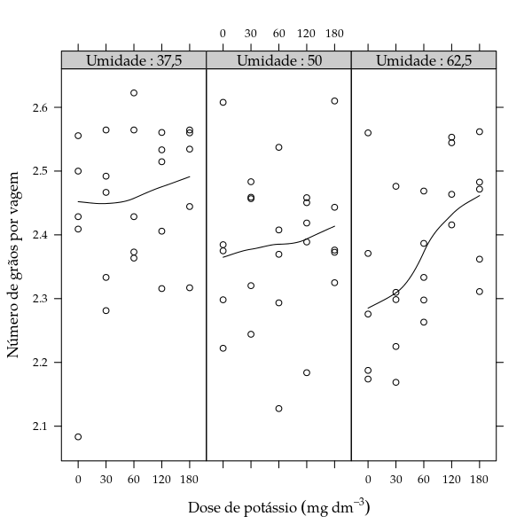

```r
#-----------------------------------------------------------------------
# Número de grãos por vagem (offset).

xyplot(ngra/nvag ~ K | umid, data = soja, layout = c(NA, 1),
       type = c("p", "smooth"),
       xlab = expression("Dose de potássio"~(mg~dm^{-3})),
       ylab = "Número de grãos por vagem",
       strip = strip.custom(strip.names = TRUE, var.name = "Umidade"))
```

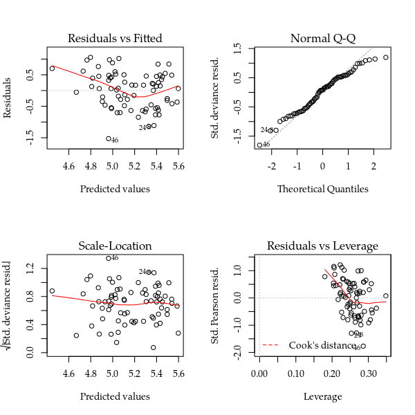

```r
#-----------------------------------------------------------------------
# Modelo Poisson.

m0 <- glm(ngra ~ offset(log(nvag)) + bloc + umid * K,
          data = soja, family = poisson)
m1 <- update(m0, family = quasipoisson)

# Diagnóstico.
par(mfrow = c(2, 2))
plot(m0); layout(1)
```

```r
# Medidas de decisão.
# anova(m0, test = "Chisq")
anova(m1, test = "F")
```

```
## Analysis of Deviance Table
##
## Model: quasipoisson, link: log
##
## Response: ngra
##
## Terms added sequentially (first to last)
##
##
##        Df Deviance Resid. Df Resid. Dev      F  Pr(>F)
## NULL                      73     34.238
## bloc    4   2.0264        69     32.212 1.1637 0.33686
## umid    2   1.7457        67     30.466 2.0050 0.14439
## K       4   3.8324        63     26.634 2.2009 0.08082 .
## umid:K  8   2.6490        55     23.984 0.7606 0.63838
## ---
## Signif. codes:  0 '***' 0.001 '**' 0.01 '*' 0.05 '.' 0.1 ' ' 1
```

```r
summary(m1)
```

```
##
## Call:
## glm(formula = ngra ~ offset(log(nvag)) + bloc + umid * K, family = quasipoisson,
##     data = soja)
##
## Deviance Residuals:
##      Min        1Q    Median        3Q       Max
## -1.52741  -0.46025   0.06782   0.45274   1.05490
##
## Coefficients:
##                Estimate Std. Error t value Pr(>|t|)
## (Intercept)    0.848160   0.029477  28.774   <2e-16 ***
## blocII         0.011313   0.017535   0.645   0.5215
## blocIII        0.036250   0.017615   2.058   0.0444 *
## blocIV         0.019384   0.017940   1.080   0.2846
## blocV          0.016100   0.018448   0.873   0.3866
## umid50        -0.001908   0.037574  -0.051   0.9597
## umid62,5      -0.031173   0.037124  -0.840   0.4047
## K30            0.022867   0.036200   0.632   0.5302
## K60            0.034499   0.035862   0.962   0.3403
## K120           0.035322   0.035703   0.989   0.3268
## K180           0.040586   0.036221   1.121   0.2674
## umid50:K30    -0.018692   0.049385  -0.378   0.7065
## umid62,5:K30  -0.028459   0.049680  -0.573   0.5691
## umid50:K60    -0.048182   0.048583  -0.992   0.3257
## umid62,5:K60  -0.014035   0.048103  -0.292   0.7716
## umid50:K120   -0.030438   0.048367  -0.629   0.5317
## umid62,5:K120  0.045524   0.048714   0.935   0.3541
## umid50:K180   -0.016302   0.048354  -0.337   0.7373
## umid62,5:K180  0.016911   0.048076   0.352   0.7264
## ---
## Signif. codes:  0 '***' 0.001 '**' 0.01 '*' 0.05 '.' 0.1 ' ' 1
##
## (Dispersion parameter for quasipoisson family taken to be 0.4353299)
##
##     Null deviance: 34.238  on 73  degrees of freedom
## Residual deviance: 23.984  on 55  degrees of freedom
## AIC: NA
##
## Number of Fisher Scoring iterations: 3
```

```r
# Declara um modelo aditivo.
m0 <- glm(ngra ~ offset(log(nvag)) + bloc + umid + K,
          data = soja, family = poisson)
m1 <- update(m0, family = quasipoisson)
anova(m1, test = "F")
```

```
## Analysis of Deviance Table
##
## Model: quasipoisson, link: log
##
## Response: ngra
##
## Terms added sequentially (first to last)
##
##
##      Df Deviance Resid. Df Resid. Dev      F  Pr(>F)
## NULL                    73     34.238
## bloc  4   2.0264        69     32.212 1.2021 0.31880
## umid  2   1.7457        67     30.466 2.0711 0.13455
## K     4   3.8324        63     26.634 2.2734 0.07114 .
## ---
## Signif. codes:  0 '***' 0.001 '**' 0.01 '*' 0.05 '.' 0.1 ' ' 1
```

```r
#-----------------------------------------------------------------------
# Modelo Poisson Generalizado.

L <- with(soja,
          list(y = ngra, offset = nvag, X = model.matrix(m0)))

start <- c(alpha = 0, coef(m0))
parnames(llgcnt) <- names(start)

# Com alpha fixo em 0 corresponde à Poisson.
m2 <- mle2(llgcnt, start = start, data = L,
           fixed = list(alpha = 0), vecpar = TRUE)

# Mesma medida de ajuste e estimativas.
c(logLik(m2), logLik(m0))
```

```
## [1] -272.6263 -272.6263
```

```r
# Poisson Generalizada.
m3 <- mle2(llgcnt, start = start, data = L, vecpar = TRUE)

# Teste para nulinidade do parâmetro de dispersão (H_0: alpha == 0).
anova(m3, m2)
```

```
## Likelihood Ratio Tests
## Model 1: m3, [llgcnt]: alpha+(Intercept)+blocII+blocIII+blocIV+
##           blocV+umid50+umid62,5+K30+K60+K120+K180
## Model 2: m2, [llgcnt]: (Intercept)+blocII+blocIII+blocIV+blocV+
##           umid50+umid62,5+K30+K60+K120+K180
##   Tot Df Deviance  Chisq Df Pr(>Chisq)
## 1     12   517.26
## 2     11   545.25 27.989  1   1.22e-07 ***
## ---
## Signif. codes:  0 '***' 0.001 '**' 0.01 '*' 0.05 '.' 0.1 ' ' 1
```

```r
c0 <- cbind("PoissonGLM" = c(NA, coef(m0)),
            "PoissonML" = coef(m2),
            "GCount" = coef(m3))
c0
```

```
##               PoissonGLM    PoissonML      GCount
##                       NA  0.000000000  1.01872022
## (Intercept)  0.855552235  0.855552234  0.85824271
## blocII       0.011126118  0.011126118  0.01116767
## blocIII      0.036245340  0.036245340  0.03631263
## blocIV       0.018895822  0.018895822  0.01904826
## blocV        0.012659290  0.012659290  0.01284491
## umid50      -0.026631767 -0.026631767 -0.02708107
## umid62,5    -0.026250165 -0.026250165 -0.02670737
## K30          0.007448488  0.007448488  0.00687900
## K60          0.012551823  0.012551823  0.01172824
## K120         0.039757260  0.039757260  0.03886651
## K180         0.041632187  0.041632187  0.04072724
```

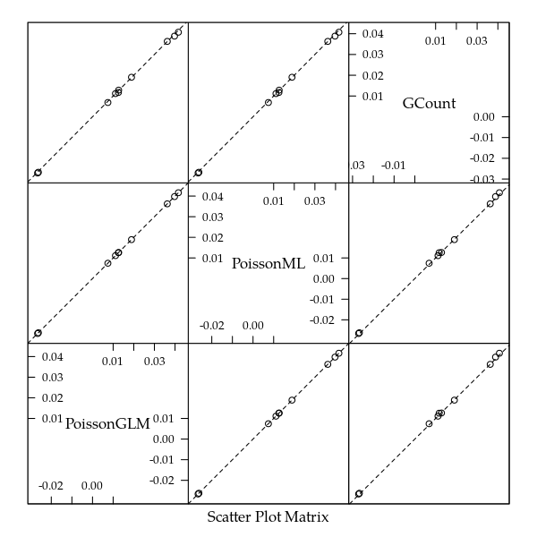

```r
splom(c0[-(1:2), ]) + layer(panel.abline(a = 0, b = 1, lty = 2))
```

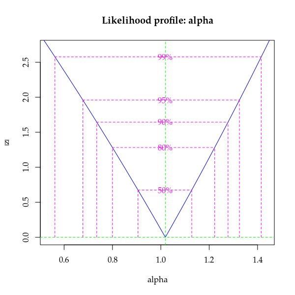

```r
# Perfil para o parâmetro de dispersão.
plot(profile(m3, which = "alpha"))
```

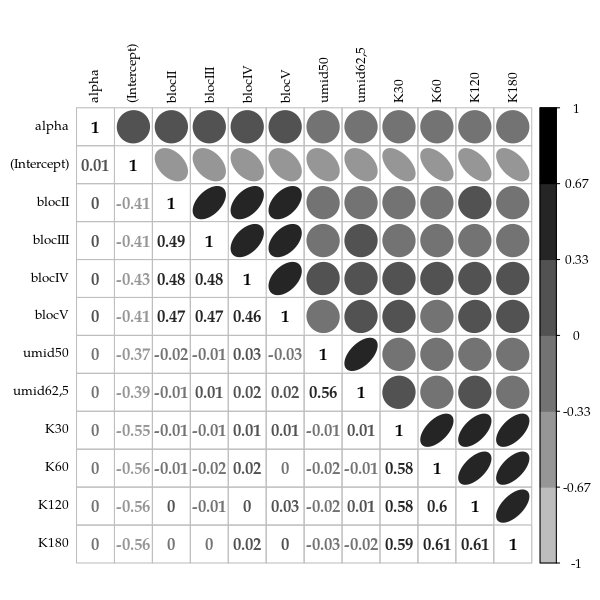

```r
V <- cov2cor(vcov(m3))
corrplot.mixed(V, lower = "number", upper = "ellipse",
               diag = "l", tl.pos = "lt", tl.col = "black",
               tl.cex = 0.8, col = brewer.pal(9, "Greys")[-(1:3)])
```

```r
dev.off()
```

```r
# Tamanho das covariâncias com \alpha.
each(sum, mean, max)(abs(V[1, -1]))
```

```
##         sum        mean         max
## 0.038796736 0.003526976 0.013298824
```

```r
# Teste de Wald para a interação.
a <- c(0, attr(model.matrix(m0), "assign"))
ai <- a == max(a)
L <- t(replicate(sum(ai), rbind(coef(m3) * 0), simplify = "matrix"))
L[, ai] <- diag(sum(ai))

# Cáclculo da estatística Chi-quadrado.
crossprod(L %*% coef(m3),
          solve(L %*% vcov(m3) %*% t(L),
                L %*% coef(m3)))
```

```
##          [,1]
## [1,] 10.33342
```

```r
linearHypothesis(model = m0,
                 hypothesis.matrix = L,
                 vcov. = vcov(m3),
                 coef. = coef(m3))
```

```
## Linear hypothesis test
##
## Hypothesis:
## K30 = 0
## K60 = 0
## K120 = 0
## K180 = 0
##
## Model 1: restricted model
## Model 2: ngra ~ offset(log(nvag)) + bloc + umid + K
##
## Note: Coefficient covariance matrix supplied.
##
##   Res.Df Df  Chisq Pr(>Chisq)
## 1     67
## 2     63  4 10.333    0.03517 *
## ---
## Signif. codes:  0 '***' 0.001 '**' 0.01 '*' 0.05 '.' 0.1 ' ' 1
```

```r
#-----------------------------------------------------------------------

# X <- model.matrix(m0)
# soja$nvag
#
# cbind(y = soja$ngra,
#       Pois = soja$nvag * exp(X %*% coef(m0)),
#       Quas = soja$nvag * exp(X %*% coef(m1)),
#       Gcnt = exp(X %*% coef(m3)[-1]))
#
# cbind(y = soja$ngra/soja$nvag,
#       Pois = exp(X %*% coef(m0)),
#       Quas = exp(X %*% coef(m1)),
#       Gcnt = exp(X %*% coef(m3)[-1]))
#
# fitted.gcnt(lambda = 1, alpha = 1)
# fitted.gcnt(lambda = 2, alpha = 1)
# fitted.gcnt(lambda = 2, alpha = 0.4)
# fitted.gcnt(lambda = 2, alpha = 3.1)

#-----------------------------------------------------------------------
# Predição com bandas de confiança.

# Por causa do offset, não tem como usar a LSmatrix.
pred <- unique(subset(soja, select = c("umid", "K")))

X <- model.matrix(formula(m0)[-2],
                  data = cbind(nvag = 1, bloc = soja$bloc[1], pred))

i <- grep(x = colnames(X), pattern = "^bloc")
X[, i] <- X[, i] * 0 + 1/(length(i) + 1)
head(X)
```

```
##   (Intercept) blocII blocIII blocIV blocV umid50 umid62,5 K30 K60
## 1           1    0.2     0.2    0.2   0.2      0        0   0   0
## 2           1    0.2     0.2    0.2   0.2      0        0   1   0
## 3           1    0.2     0.2    0.2   0.2      0        0   0   1
## 4           1    0.2     0.2    0.2   0.2      0        0   0   0
## 5           1    0.2     0.2    0.2   0.2      0        0   0   0
## 6           1    0.2     0.2    0.2   0.2      1        0   0   0
##   K120 K180
## 1    0    0
## 2    0    0
## 3    0    0
## 4    1    0
## 5    0    1
## 6    0    0
```

```r
pred <- list(pois = pred, quasi = pred, gcnt = pred)

# Quantil normal.
qn <- qnorm(0.975) * c(lwr = -1, fit = 0, upr = 1)

# Preditos pela Poisson.
aux <- confint(glht(m0, linfct = X),
               calpha = univariate_calpha())$confint
colnames(aux)[1] <- "fit"
pred$pois <- cbind(pred$pois, exp(aux))

# Preditos pela Quasi-Poisson.
aux <- confint(glht(m1, linfct = X),
               calpha = univariate_calpha())$confint
colnames(aux)[1] <- "fit"
pred$quasi <- cbind(pred$quasi, exp(aux))

# # TODO
# m3 <- m2

# Matrix de covariância completa e sem o alpha (marginal).
V <- vcov(m3)
V <- V[-1, -1]
U <- chol(V)
aux <- sqrt(apply(X %*% t(U), MARGIN = 1,
                  FUN = function(x) { sum(x^2) }))
pred$gcnt$eta <- c(X %*% coef(m3)[-1])

# Comparando as estimativas de média para contagem.
c(Pois = pred$pois$fit[1],
  Gcnt1 = exp(pred$gcnt$eta)[1],
  GCnt2 = fitted.gcnt(
      lambda = exp(pred$gcnt$eta)[1],
      alpha = exp(coef(m3)["alpha"]),
      ymax = 80))
```

```
##     Pois    Gcnt1    GCnt2
## 2.390106 2.396759 2.077286
```

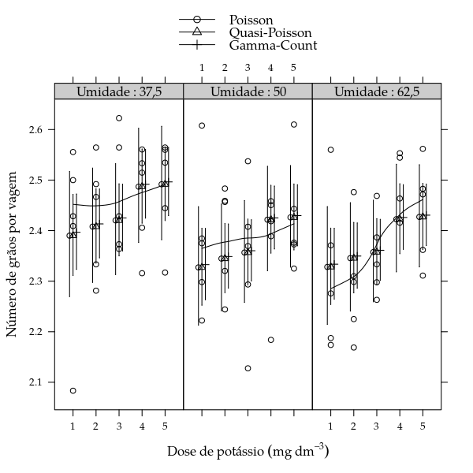

```r
pred$gcnt <- cbind(pred$gcnt,
                   apply(outer(aux, qn, FUN = "*"), MARGIN = 2,
                         FUN = function(x) {
                             exp(pred$gcnt$eta + x)
                             # fitted.gcnt(
                             #     lambda = exp(pred$gcnt$eta + x),
                             #     alpha = exp(coef(m3)["alpha"]),
                             #     ymax = 50)
                         }))
pred$gcnt$eta <- NULL

# Junta o resultado dos 3 modelos.
pred <- ldply(pred, .id = "modelo")
pred <- arrange(pred, umid, K, modelo)

key <- list(type = "o", divide = 1,
            lines = list(pch = 1:nlevels(pred$modelo),
                         lty = 1, col = 1),
            text = list(c("Poisson", "Quasi-Poisson",
                          "Gamma-Count")))

xyplot(ngra/nvag ~ K | umid, data = soja, layout = c(NA, 1),
       type = c("p", "smooth"),
       xlim = extendrange(range(as.numeric(pred$K)), f = 0.2),
       key = key,
       xlab = expression("Dose de potássio"~(mg~dm^{-3})),
       ylab = "Número de grãos por vagem",
       strip = strip.custom(strip.names = TRUE, var.name = "Umidade")) +
    as.layer(
        xyplot(fit ~ K | umid, data = pred,
               layout = c(NA, 1), as.table = TRUE,
               pch = pred$modelo,
               ly = pred$lwr, uy = pred$upr, cty = "bars", length = 0,
               prepanel = prepanel.cbH,
               desloc = 0.15 * scale(as.integer(pred$modelo),
                                  scale = FALSE),
               panel = panel.cbH))
```

## Número de Capulhos Produzidos em Algodão

Experimento conduzido em casa de vegetação para avaliar o efeito da desfolha, em diferentes fases de desenvolvimento do algodão, sobre a produção da cultura. As parcelas foram vasos com duas plantas que tiveram a área das folhas removida com uma tesoura, simulando o ataque de insetos desfolhadores, nos níveis de 0, 25, 50, 75 e 100% de remoção de área foliar. Em cada fase de desenvolvimento (de 5), 5 parcelas sofreram desfolha nos níveis mencionados. Trata-se então de um experimento em arranjo fatorial 5 desfolhas $\times$ 5 fases com 5 repetições por cela. O número de capulhos ao final do experimento foi contado.

```r
#-----------------------------------------------------------------------
# Número de capulhos em função do nível de desfolha artificial e fase
# fenológica do algodoeiro.

data(capdesfo, package = "MRDCr")
str(capdesfo)
```

```
## 'data.frame':    125 obs. of  4 variables:
##  $ est : Factor w/ 5 levels "vegetativo","botão floral",..: 1 1 1 1 1 1 1 1 1 1 ...
##  $ des : num  0 0 0 0 0 0.25 0.25 0.25 0.25 0.25 ...
##  $ rept: int  1 2 3 4 5 1 2 3 4 5 ...
##  $ ncap: int  10 9 8 8 10 11 9 10 10 10 ...
```

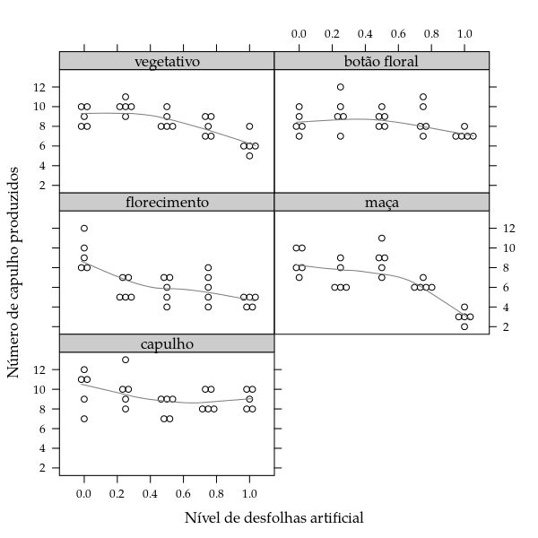

```r
# help(capdesfo, package = "MRDCr", help_type = "html")

p1 <- xyplot(ncap ~ des | est, data = capdesfo,
             col = 1, type = c("p", "smooth"), col.line = "gray50",
             layout = c(2, 3), as.table = TRUE,
             xlim = extendrange(capdesfo$des, f = 0.15),
             xlab = "Nível de desfolhas artificial",
             ylab = "Número de capulho produzidos",
             spread = 0.035, panel = panel.beeswarm)
p1
```

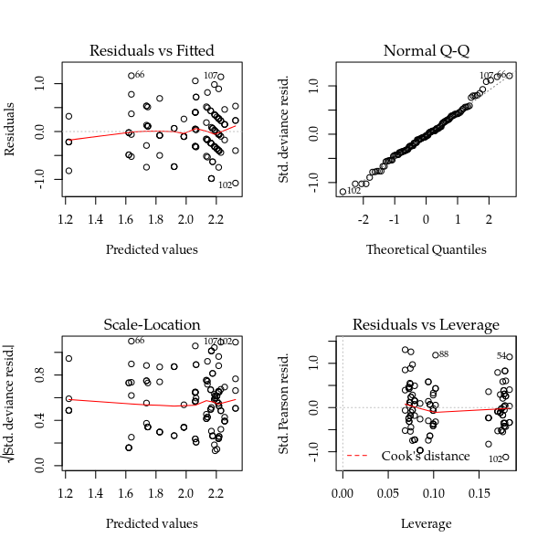

```r
#-----------------------------------------------------------------------
# Modelo Poisson.

m0 <- glm(ncap ~ est * (des + I(des^2)),
          data = capdesfo, family = poisson)
m1 <- update(m0, family = quasipoisson)

par(mfrow = c(2, 2))
plot(m0); layout(1)
```

```r
# anova(m0, test = "Chisq")
anova(m1, test = "F")
```

```
## Analysis of Deviance Table
##
## Model: quasipoisson, link: log
##
## Response: ncap
##
## Terms added sequentially (first to last)
##
##
##              Df Deviance Resid. Df Resid. Dev       F    Pr(>F)
## NULL                           124     75.514
## est           4  19.9582       120     55.556 21.5543 3.775e-13 ***
## des           1  15.8643       119     39.692 68.5317 3.269e-13 ***
## I(des^2)      1   1.2926       118     38.399  5.5839   0.01988 *
## est:des       4   6.7085       114     31.691  7.2450 3.236e-05 ***
## est:I(des^2)  4   6.3592       110     25.331  6.8677 5.674e-05 ***
## ---
## Signif. codes:  0 '***' 0.001 '**' 0.01 '*' 0.05 '.' 0.1 ' ' 1
```

```r
summary(m1)
```

```
##
## Call:
## glm(formula = ncap ~ est * (des + I(des^2)), family = quasipoisson,
##     data = capdesfo)
##
## Deviance Residuals:
##      Min        1Q    Median        3Q       Max
## -1.07706  -0.30981  -0.02283   0.27044   1.16650
##
## Coefficients:
##                          Estimate Std. Error t value Pr(>|t|)
## (Intercept)               2.21424    0.06706  33.018  < 2e-16 ***
## estbotão floral          -0.08003    0.09655  -0.829  0.40898
## estflorecimento          -0.02723    0.09626  -0.283  0.77781
## estmaça                  -0.14861    0.09867  -1.506  0.13489
## estcapulho                0.11291    0.09247   1.221  0.22465
## des                       0.34859    0.32741   1.065  0.28935
## I(des^2)                 -0.73843    0.32397  -2.279  0.02458 *
## estbotão floral:des       0.13638    0.46401   0.294  0.76937
## estflorecimento:des      -1.58189    0.49140  -3.219  0.00169 **
## estmaça:des               0.47548    0.49046   0.969  0.33444
## estcapulho:des           -0.82100    0.45204  -1.816  0.07206 .
## estbotão floral:I(des^2)  0.10435    0.45451   0.230  0.81884
## estflorecimento:I(des^2)  1.40435    0.49033   2.864  0.00501 **
## estmaça:I(des^2)         -0.92938    0.49667  -1.871  0.06397 .
## estcapulho:I(des^2)       1.07565    0.44314   2.427  0.01683 *
## ---
## Signif. codes:  0 '***' 0.001 '**' 0.01 '*' 0.05 '.' 0.1 ' ' 1
##
## (Dispersion parameter for quasipoisson family taken to be 0.2314882)
##
##     Null deviance: 75.514  on 124  degrees of freedom
## Residual deviance: 25.331  on 110  degrees of freedom
## AIC: NA
##
## Number of Fisher Scoring iterations: 4
```

```r
#-----------------------------------------------------------------------
# Modelo Poisson Generalizada.

L <- with(capdesfo,
          list(y = ncap, offset = 1, X = model.matrix(m0)))

start <- c(alpha = log(1), coef(m0))
parnames(llgcnt) <- names(start)

# Modelo Poisson também.
m2 <- mle2(llgcnt, start = start, data = L,
           fixed = list(alpha = 0), vecpar = TRUE)

c(logLik(m2), logLik(m0))
```

```
## [1] -254.8414 -254.8414
```

```r
# Modelo Poisson Generalizado.
m3 <- mle2(llgcnt, start = start, data = L, vecpar = TRUE)
logLik(m3)
```

```
## 'log Lik.' -203.7501 (df=16)
```

```r
anova(m3, m2)
```

```
## Likelihood Ratio Tests
## Model 1: m3, [llgcnt]: alpha+(Intercept)+estbotão floral+
##           estflorecimento+estmaça+estcapulho+des+I(des^2)+
##           estbotão floral:des+estflorecimento:des+estmaça:des+
##           estcapulho:des+estbotão floral:I(des^2)+
##           estflorecimento:I(des^2)+estmaça:I(des^2)+
##           estcapulho:I(des^2)
## Model 2: m2, [llgcnt]: (Intercept)+estbotão floral+
##           estflorecimento+estmaça+estcapulho+des+I(des^2)+
##           estbotão floral:des+estflorecimento:des+estmaça:des+
##           estcapulho:des+estbotão floral:I(des^2)+
##           estflorecimento:I(des^2)+estmaça:I(des^2)+
##           estcapulho:I(des^2)
##   Tot Df Deviance  Chisq Df Pr(>Chisq)
## 1     16   407.50
## 2     15   509.68 102.18  1  < 2.2e-16 ***
## ---
## Signif. codes:  0 '***' 0.001 '**' 0.01 '*' 0.05 '.' 0.1 ' ' 1
```

```r
summary(m3)
```

```
## Maximum likelihood estimation
##
## Call:
## mle2(minuslogl = llgcnt, start = start, data = L, vecpar = TRUE)
##
## Coefficients:
##                           Estimate Std. Error z value     Pr(z)
## alpha                     1.710979   0.135195 12.6556 < 2.2e-16 ***
## (Intercept)               2.258038   0.059339 38.0532 < 2.2e-16 ***
## estbotão floral          -0.076524   0.085405 -0.8960 0.3702456
## estflorecimento          -0.025313   0.085113 -0.2974 0.7661593
## estmaça                  -0.139845   0.087219 -1.6034 0.1088485
## estcapulho                0.108438   0.081763  1.3263 0.1847562
## des                       0.329398   0.289643  1.1373 0.2554329
## I(des^2)                 -0.699663   0.286619 -2.4411 0.0146430 *
## estbotão floral:des       0.133744   0.410476  0.3258 0.7445554
## estflorecimento:des      -1.501986   0.434453 -3.4572 0.0005459 ***
## estmaça:des               0.421813   0.433578  0.9729 0.3306201
## estcapulho:des           -0.782023   0.399797 -1.9561 0.0504593 .
## estbotão floral:I(des^2)  0.094333   0.402116  0.2346 0.8145248
## estflorecimento:I(des^2)  1.338205   0.433533  3.0867 0.0020236 **
## estmaça:I(des^2)         -0.833309   0.439023 -1.8981 0.0576829 .
## estcapulho:I(des^2)       1.022210   0.391972  2.6079 0.0091108 **
## ---
## Signif. codes:  0 '***' 0.001 '**' 0.01 '*' 0.05 '.' 0.1 ' ' 1
##
## -2 log L: 407.5003
```

```r
c0 <- cbind("PoissonGLM" = c(NA, coef(m0)),
            "PoissonML" = coef(m2),
            "GCount" = coef(m3))
c0
```

```
##                           PoissonGLM   PoissonML      GCount
##                                   NA  0.00000000  1.71097890
## (Intercept)               2.21424242  2.21424242  2.25803759
## estbotão floral          -0.08002756 -0.08002756 -0.07652439
## estflorecimento          -0.02722855 -0.02722855 -0.02531284
## estmaça                  -0.14861263 -0.14861263 -0.13984549
## estcapulho                0.11291268  0.11291268  0.10843781
## des                       0.34858564  0.34858564  0.32939763
## I(des^2)                 -0.73843427 -0.73843427 -0.69966320
## estbotão floral:des       0.13638395  0.13638395  0.13374406
## estflorecimento:des      -1.58188650 -1.58188650 -1.50198575
## estmaça:des               0.47548300  0.47548300  0.42181332
## estcapulho:des           -0.82100307 -0.82100307 -0.78202287
## estbotão floral:I(des^2)  0.10435096  0.10435096  0.09433350
## estflorecimento:I(des^2)  1.40435178  1.40435178  1.33820484
## estmaça:I(des^2)         -0.92937720 -0.92937720 -0.83330941
## estcapulho:I(des^2)       1.07565430  1.07565430  1.02220995
```

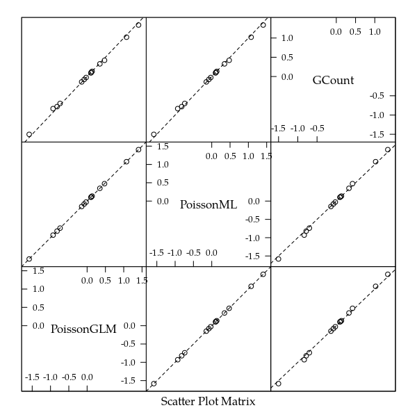

```r
splom(c0[-(1:2), ]) + layer(panel.abline(a = 0, b = 1, lty = 2))
```

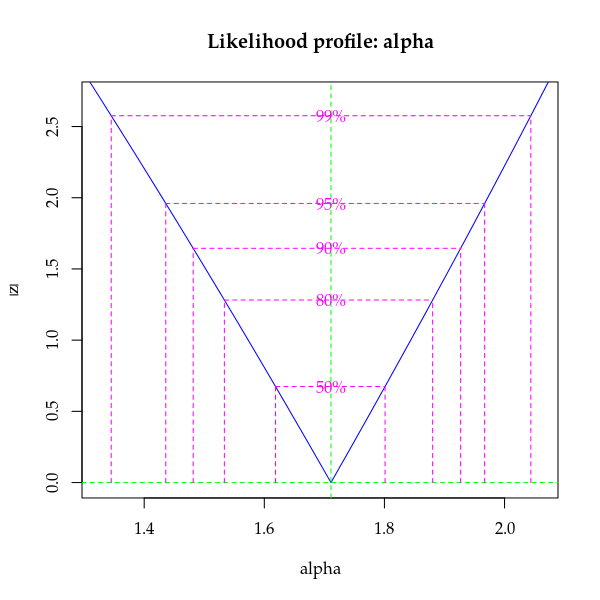

```r
# Perfil para o parâmetro de dispersão.
plot(profile(m3, which = "alpha"))
```

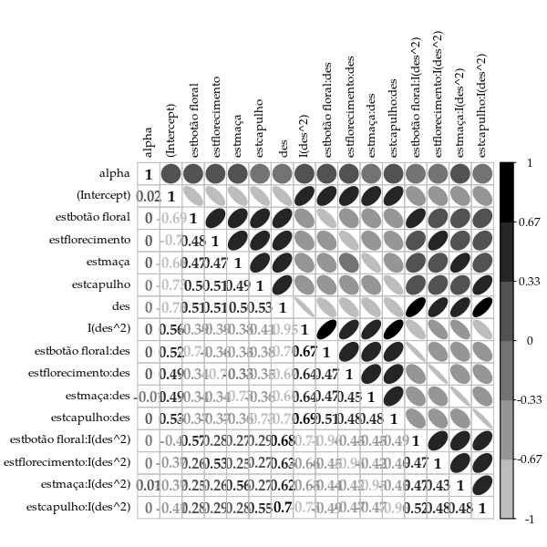

```r
V <- cov2cor(vcov(m3))
corrplot.mixed(V, lower = "number", upper = "ellipse",
               diag = "l", tl.pos = "lt", tl.col = "black",
               tl.cex = 0.8, col = brewer.pal(9, "Greys")[-(1:3)])
```

```r
dev.off()
```

```r
# Tamanho das covariâncias com \alpha.
each(sum, mean, max)(abs(V[1, -1]))
```

```
##         sum        mean         max
## 0.070733515 0.004715568 0.022155377
```

```r
# Teste de Wald para a interação.
a <- c(0, attr(model.matrix(m0), "assign"))
ai <- a == max(a)
L <- t(replicate(sum(ai), rbind(coef(m3) * 0), simplify = "matrix"))
L[, ai] <- diag(sum(ai))

# Teste de Wald explicito.
crossprod(L %*% coef(m3),
          solve(L %*% vcov(m3) %*% t(L),
                L %*% coef(m3)))
```

```
##          [,1]
## [1,] 30.51573
```

```r
# Teste de Wald para interação (poderia ser LRT, claro).
# É necessário um objeto glm, mas necesse caso ele não usado para nada.
linearHypothesis(model = m0,
                 hypothesis.matrix = L,
                 vcov. = vcov(m3),
                 coef. = coef(m3))
```

```
## Linear hypothesis test
##
## Hypothesis:
## estbotão floral:I(des^2) = 0
## estflorecimento:I(des^2) = 0
## estmaça:I(des^2) = 0
## estcapulho:I(des^2) = 0
##
## Model 1: restricted model
## Model 2: ncap ~ est * (des + I(des^2))
##
## Note: Coefficient covariance matrix supplied.
##
##   Res.Df Df  Chisq Pr(>Chisq)
## 1    114
## 2    110  4 30.516  3.843e-06 ***
## ---
## Signif. codes:  0 '***' 0.001 '**' 0.01 '*' 0.05 '.' 0.1 ' ' 1
```

```r
#-----------------------------------------------------------------------
# Predição com bandas de confiança.

pred <- with(capdesfo, expand.grid(est = levels(est),
                                   des = seq(0, 1, by = 0.025)))
X <- model.matrix(formula(m0)[-2], data = pred)
pred <- list(pois = pred, quasi = pred, gcnt = pred)

# Quantil normal.
qn <- qnorm(0.975) * c(lwr = -1, fit = 0, upr = 1)

# Preditos pela Poisson.
aux <- confint(glht(m0, linfct = X),
               calpha = univariate_calpha())$confint
colnames(aux)[1] <- "fit"
pred$pois <- cbind(pred$pois, exp(aux))

# Preditos pela Quasi-Poisson.
aux <- confint(glht(m1, linfct = X),
               calpha = univariate_calpha())$confint
colnames(aux)[1] <- "fit"
pred$quasi <- cbind(pred$quasi, exp(aux))

# Preditos pela Poisson Generalizada.
V <- vcov(m3)
V <- V[-1, -1]
U <- chol(V)
aux <- sqrt(apply(X %*% t(U), MARGIN = 1,
                  FUN = function(x) { sum(x^2) }))
pred$gcnt$eta <- c(X %*% coef(m3)[-1])

# Comparando as estimativas de média para contagem.
c(Pois = pred$pois$fit[1],
  Gcnt1 = exp(pred$gcnt$eta)[1],
  GCnt2 = fitted.gcnt(
      lambda = exp(pred$gcnt$eta)[1],
      alpha = exp(coef(m3)["alpha"]),
      ymax = 30))
```

```
##     Pois    Gcnt1    GCnt2
## 9.154471 9.564302 9.154646
```

```r
pred$gcnt <- cbind(pred$gcnt,
                   apply(outer(aux, qn, FUN = "*"), MARGIN = 2,
                         FUN = function(x) {
                             # exp(pred$gcnt$eta + x)
                             fitted.gcnt(
                                 lambda = exp(pred$gcnt$eta + x),
                                 alpha = exp(coef(m3)["alpha"]),
                                 ymax = 50)
                         }))

pred <- ldply(pred, .id = "modelo")
pred <- arrange(pred, est, des, modelo)

key <- list(lines = list(lty = 1),
            text = list(c("Poisson", "Quasi-Poisson",
                          "Gamma-Count")))
key$lines$col <-
    trellis.par.get("superpose.line")$col[1:nlevels(pred$modelo)]

p2 <- xyplot(fit ~ des | est, data = pred, groups = modelo,
             layout = c(NA, 1), as.table = TRUE,
             xlim = extendrange(range(pred$des), f = 0.1),
             type = "l", key = key,
             ly = pred$lwr, uy = pred$upr,
             cty = "bands", alpha = 0.35,
             prepanel = prepanel.cbH,
             panel.groups = panel.cbH,
             panel = panel.superpose)
# p2
```

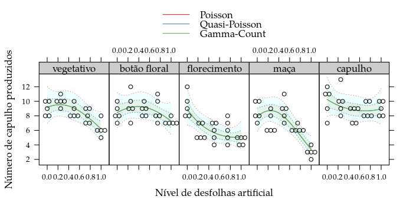

```r
update(p1, type = "p", layout = c(NA, 1),
       key = key, spread = 0.07) +
    as.layer(p2, under = TRUE)
```

## Número de Nematoides em Linhagens de Feijão

```r
#-----------------------------------------------------------------------

data(nematoide, package = "MRDCr")
str(nematoide)
```

```
## 'data.frame':    94 obs. of  5 variables:
##  $ cult: Factor w/ 19 levels "A","B","C","D",..: 1 1 1 1 1 2 2 2 2 2 ...
##  $ mfr : num  10.52 11.03 6.42 8.16 4.48 ...
##  $ vol : int  40 40 40 40 40 40 40 40 40 40 ...
##  $ nema: int  4 5 3 4 3 2 2 2 2 2 ...
##  $ off : num  0.263 0.276 0.161 0.204 0.112 ...
```

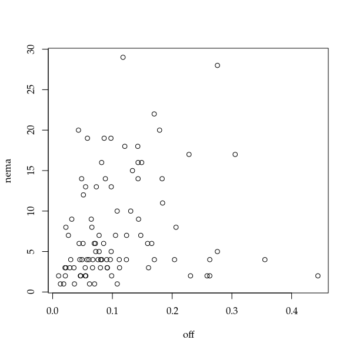

```r
# help(nematoide, package = "MRDCr", help_type = "html")

# Número de nematóides por grama de raíz.
plot(nema ~ off, data = nematoide)
```

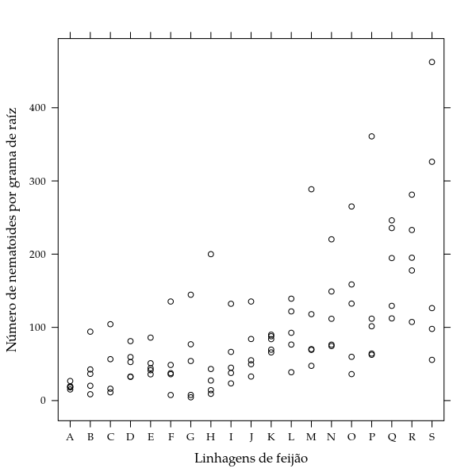

```r
xyplot(nema/off ~ cult, data = nematoide,
       xlab = "Linhagens de feijão",
       ylab = "Número de nematoides por grama de raíz")
```

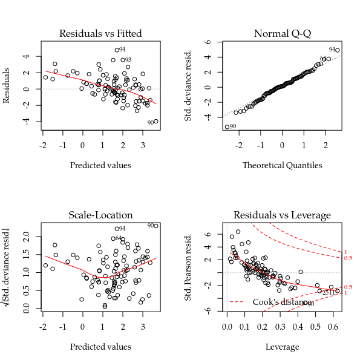

```r
#-----------------------------------------------------------------------
# Ajuste do Poisson.

m0 <- glm(nema ~ offset(log(off)) + cult,
          data = nematoide,
          family = poisson)
m1 <- update(m0, family = quasipoisson)

# Diagnóstico.
par(mfrow = c(2, 2))
plot(m0); layout(1)
```

```r
# Estimativas dos parâmetros.
summary(m1)
```

```
##
## Call:
## glm(formula = nema ~ offset(log(off)) + cult, family = quasipoisson,
##     data = nematoide)
##
## Deviance Residuals:
##     Min       1Q   Median       3Q      Max
## -3.9455  -0.6693   0.1100   1.1519   4.7603
##
## Coefficients:
##             Estimate Std. Error t value Pr(>|t|)
## (Intercept)   2.9293     0.4496   6.515 7.42e-09 ***
## cultB         0.1662     0.7657   0.217 0.828703
## cultC         0.3417     0.6769   0.505 0.615154
## cultD         0.9128     0.6359   1.436 0.155278
## cultE         0.9692     0.6076   1.595 0.114879
## cultF         0.3973     0.6903   0.576 0.566621
## cultG        -0.4507     0.7931  -0.568 0.571522
## cultH         0.3218     0.8665   0.371 0.711433
## cultI         0.8808     0.6018   1.464 0.147507
## cultJ         1.1982     0.6359   1.884 0.063390 .
## cultK         1.4511     0.5965   2.433 0.017369 *
## cultL         1.4299     0.5362   2.667 0.009381 **
## cultM         1.6138     0.5507   2.931 0.004482 **
## cultN         1.7743     0.4958   3.579 0.000610 ***
## cultO         1.5776     0.5268   2.995 0.003718 **
## cultP         1.6719     0.5103   3.277 0.001593 **
## cultQ         2.2105     0.4913   4.499 2.45e-05 ***
## cultR         2.2080     0.5103   4.327 4.60e-05 ***
## cultS         1.9155     0.4958   3.863 0.000236 ***
## ---
## Signif. codes:  0 '***' 0.001 '**' 0.01 '*' 0.05 '.' 0.1 ' ' 1
##
## (Dispersion parameter for quasipoisson family taken to be 3.841169)
##
##     Null deviance: 556.73  on 93  degrees of freedom
## Residual deviance: 212.54  on 75  degrees of freedom
## AIC: NA
##
## Number of Fisher Scoring iterations: 6
```

```r
# Quadro de deviance.
# anova(m0, test = "Chisq")
anova(m1, test = "F")
```

```
## Analysis of Deviance Table
##
## Model: quasipoisson, link: log
##
## Response: nema
##
## Terms added sequentially (first to last)
##
##
##      Df Deviance Resid. Df Resid. Dev     F    Pr(>F)
## NULL                    93     556.73
## cult 18   344.19        75     212.54 4.978 3.475e-07 ***
## ---
## Signif. codes:  0 '***' 0.001 '**' 0.01 '*' 0.05 '.' 0.1 ' ' 1
```

```r
#-----------------------------------------------------------------------
# Ajuste da Poisson Generalizada.

L <- with(nematoide,
          list(y = nema, offset = off, X = model.matrix(m0)))

start <- c(alpha = log(1), coef(m0))
parnames(llgcnt) <- names(start)

# Modelo Poisson também.
m2 <- mle2(llgcnt, start = start, data = L,
           fixed = list(alpha = 0), vecpar = TRUE)

c(logLik(m2), logLik(m0))
```

```
## [1] -274.5007 -274.5007
```

```r
# Poisson Generalizada.
m3 <- gcnt(formula(m0), data = nematoide)

# Diferença de deviance.
# 2 * diff(c(logLik(m0), logLik(m3)))
anova(m3, m2)
```

```
## Likelihood Ratio Tests
## Model 1: m3, [llgcnt]: alpha+(Intercept)+cultB+cultC+cultD+
##           cultE+cultF+cultG+cultH+cultI+cultJ+cultK+cultL+
##           cultM+cultN+cultO+cultP+cultQ+cultR+cultS
## Model 2: m2, [llgcnt]: (Intercept)+cultB+cultC+cultD+cultE+
##           cultF+cultG+cultH+cultI+cultJ+cultK+cultL+cultM+
##           cultN+cultO+cultP+cultQ+cultR+cultS
##   Tot Df Deviance  Chisq Df Pr(>Chisq)
## 1     20   488.72
## 2     19   549.00 60.278  1  8.236e-15 ***
## ---
## Signif. codes:  0 '***' 0.001 '**' 0.01 '*' 0.05 '.' 0.1 ' ' 1
```

```r
c0 <- cbind("PoissonGLM" = c(NA, coef(m0)),
            "PoissonML" = coef(m2),
            "GCount" = coef(m3))
c0
```

```
##             PoissonGLM  PoissonML      GCount
##                     NA  0.0000000 -1.14112640
## (Intercept)  2.9293041  2.9293041  2.64609924
## cultB        0.1662485  0.1662485 -0.04559607
## cultC        0.3417426  0.3417426  0.35670405
## cultD        0.9128492  0.9128492  0.91203676
## cultE        0.9692234  0.9692234  1.01528664
## cultF        0.3973326  0.3973326  0.31963344
## cultG       -0.4507108 -0.4507108 -0.63094615
## cultH        0.3217814  0.3217814 -0.11142064
## cultI        0.8808018  0.8808018  0.94473617
## cultJ        1.1982163  1.1982163  1.19639146
## cultK        1.4511238  1.4511238  1.51617919
## cultL        1.4298744  1.4298744  1.59550343
## cultM        1.6137977  1.6137977  1.75476839
## cultN        1.7743062  1.7743062  1.99708212
## cultO        1.5776191  1.5776191  1.75826104
## cultP        1.6718841  1.6718841  1.87564022
## cultQ        2.2104990  2.2104990  2.43923574
## cultR        2.2080215  2.2080215  2.41168192
## cultS        1.9154798  1.9154798  2.14065393
```